# Start codon context for Histoplasma capsulatum G217B

Edward Wallace, ewjwallace@gmail.com

16 Jan 2019

# Summary

This presents the analysis of Histoplasma capsulatum start codon usage and context. This uses the H H. capsulatum G217B translation estimates from Gilmore, Voorhies, Gebhart and Sil 2017.

We decided that the 5’UTR annotations are so patchy that we don’t want to pursue this data. Only about half the highly-translated genes have 5’UTRs in the annotation, and there are many contigs and plenty of missing genes including 6 ribosomal proteins.

# Here we go

## Expression: RNA abundance and ribosome-protected-fragments

### Load expression data

```
## # A tibble: 7,186 x 7
##    Gene                                RNA_Y RNA_H RPF_Y RPF_H   RNA   RPF
##    <chr>                               <dbl> <dbl> <dbl> <dbl> <dbl> <dbl>
##  1 HISTO_ZL.Contig1158.Fgenesh_histo.…  12.6 12.2   13.4 12.1   12.4  12.7
##  2 HISTO_DM.Contig93.eannot.1682.fina…  10.3 12.0   11.9 13.2   11.2  12.6
##  3 HISTO_DM.Contig93.eannot.1655.fina…  11.5 11.2   12.7 12.1   11.3  12.4
##  4 HISTO_KK.Contig134.Fgenesh_histo.1…  11.1 12.8   11.2 13.4   12.0  12.3
##  5 HISTO_JG.Contig206.eannot.1462.fin…  10.1 11.3   11.6 12.9   10.7  12.2
##  6 HISTO_AL.Contig317.eannot.1560.fin…  14.0  9.68  14.4 10.0   11.9  12.2
##  7 HISTO_DM.Contig940.fgenesh_plus.23…  10.0 11.5   11.3 12.9   10.7  12.1
##  8 HISTO_ZL.Contig1117.eannot.1110.fi…  15.1  7.39  15.8  8.25  11.2  12.0
##  9 <NA>                                 14.0 12.9   12.0 11.9   13.4  12.0
## 10 HISTO_ZU.Contig65.eannot.1990.fina…  11.3 11.3   12.1 11.3   11.3  11.7
## # ... with 7,176 more rows
```

## ATG Context

### Load context data

```
## # A tibble: 10,684 x 19
##    Gene  aATG.context aATG.pos d1.context d1.posTSS d1.posATG d1.frame
##    <chr> <chr>           <dbl> <chr>          <dbl>     <dbl>    <dbl>
##  1 HIST… TGATCTTCATC…        1 GGACATTGA…        51        50        2
##  2 HIST… GGTTAGTCGGC…        1 TTGACTCCC…       104       103        1
##  3 HIST… TCCTTGGATTC…      318 CTACTTAAA…       359        41        2
##  4 HIST… GATATATCAAG…        1 GCTGCGACA…        18        17        2
##  5 HIST… AAACTGATCAT…        1 TTTTCTGTT…        22        21        0
##  6 HIST… CAGTGTTACAA…        1 AGACATTAT…       163       162        0
##  7 HIST… AAGCGGTGGAG…        1 TGGTTTAAT…        16        15        0
##  8 HIST… AGAGAGTAGAT…        1 CGGCGGCGC…        65        64        1
##  9 HIST… CCGGATGATGG…        1 CCGGATACC…        49        48        0
## 10 HIST… GGAGCTTGCCC…      557 GCAGGAAAA…       572        15        0
## # ... with 10,674 more rows, and 12 more variables: d2.context <chr>,
## #   d2.posTSS <dbl>, d2.posATG <dbl>, d2.frame <dbl>, u1.context <chr>,
## #   u1.posTSS <dbl>, u1.posATG <dbl>, u1.frame <dbl>, u2.context <chr>,
## #   u2.posTSS <dbl>, u2.posATG <dbl>, u2.frame <dbl>
```

### Annotated ATGs have a Kozak consensus sequence

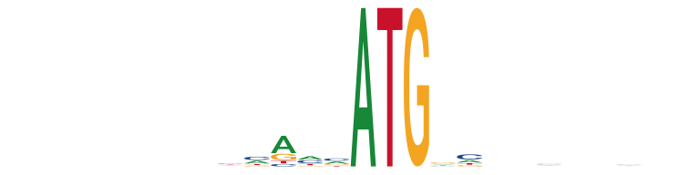

### Highly translated Annotated ATGs have a Kozak consensus sequence

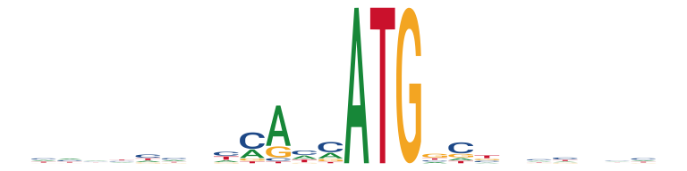

#### Consensus is more visible on genes with 5’UTR annotation.

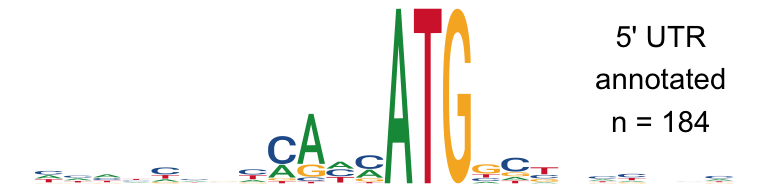

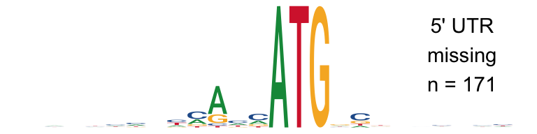

### Cytoplasmic Ribosome Annotated ATGs have a Kozak consensus sequence

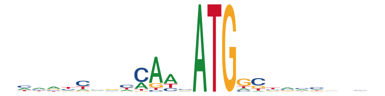

#### Consensus is more visible on genes with 5’UTR annotation.

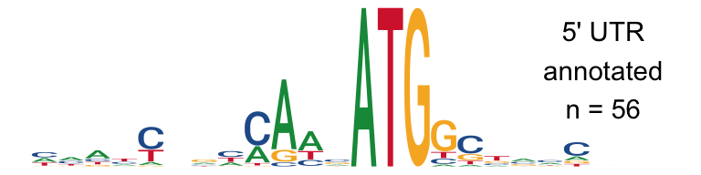

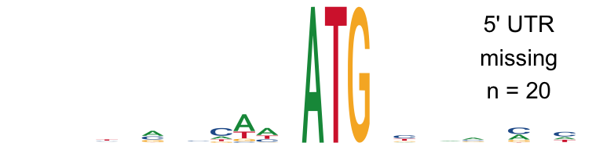

### Upstream ATGs don’t have a consensus

First upstream ATG

[figure not shown]

### Most cytoribo genes are highly translated

Venn diagram

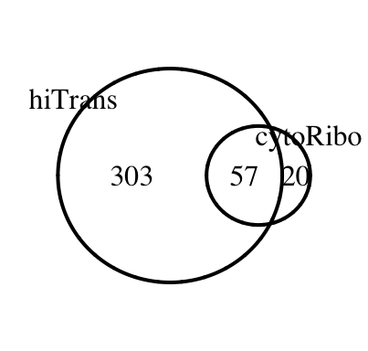

### Downstream ATGs don’t have a consensus

First downstream ATG

[figure not shown]

### Downstream ATGs in frame and highly translated don’t have a consensus

Except for 3rd-codon-position bias.

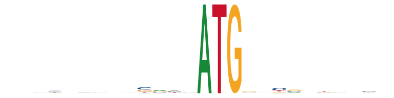

## Calculate Information content and scores of consensus motif

### Calculate a wide and a narrow consensus sequence

Calculate motif score against the position weight matrix (pwm) for both **narrow** (-4 from ATG through to ATG) and **wide** (-10 from ATG) kozak consensus motif. These motifs are taken from the top 5% highly translated genes.

### Estimate the information content

Using the sequence logo, details on https://en.wikipedia.org/wiki/Sequence_logo

```
## # A tibble: 6 x 4
##   Genes    ATG   Width   Infon
##   <chr>    <chr> <chr>   <dbl>
## 1 All      aATG  narrow 0.768
## 2 HiTrans  aATG  narrow 1.58
## 3 CytoRibo aATG  narrow 1.82
## 4 All      d1ATG narrow 0.0654
## 5 HiTrans  d1ATG narrow 0.208
## 6 CytoRibo d1ATG narrow 0.304
```

### Calculate scores of aATG, dATG, uATG against Kozak consensus

We calculate scores using Biostrings::PWMscoreStartingAt.

The best description I could find of this method is: https://support.bioconductor.org/p/61520/

It is just the sum of the matrix product of the PWM with the sequence.

Write scores to file *scores_kozak_Hc.txt*.

```
## # A tibble: 10,684 x 11
##    Gene  aATG.scorekn d1.scorekn u1.scorekn aATG.scorekw d1.scorekw
##    <chr>        <dbl>      <dbl>      <dbl>        <dbl>      <dbl>
##  1 HIST…        0.865      0.872     NA            0.864      0.809
##  2 HIST…        0.897      0.905     NA            0.853      0.870
##  3 HIST…        0.821      0.877      0.797        0.786      0.832
##  4 HIST…        0.924      0.912     NA            0.894      0.855
##  5 HIST…        0.987      0.838     NA            0.930      0.835
##  6 HIST…        0.994      0.862     NA            0.899      0.820
##  7 HIST…        0.884      0.797     NA            0.773      0.747
##  8 HIST…        0.926      0.887     NA            0.843      0.776
##  9 HIST…        0.795      0.987     NA            0.730      0.899
## 10 HIST…        0.875      0.936      0.823        0.810      0.853
## # ... with 10,674 more rows, and 5 more variables: u1.scorekw <dbl>,
## #   d1vsan <dbl>, u1vsan <dbl>, d1vsaw <dbl>, u1vsaw <dbl>
```

### Plot against narrow consensus (-4 to ATG)

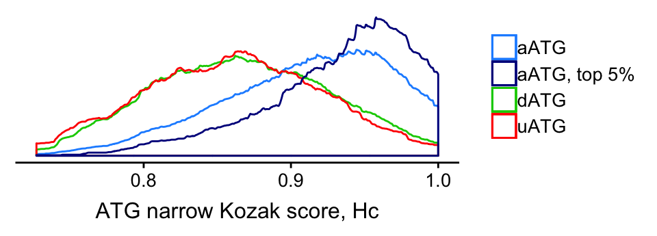

### Plot against wide consensus (-10 to ATG)

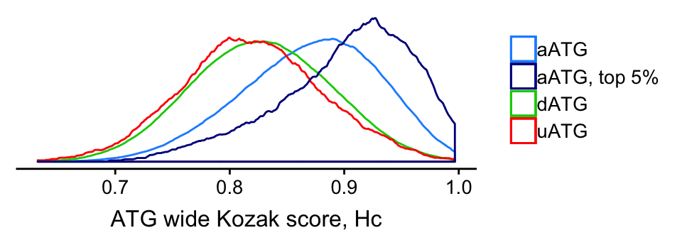

## Compare aATG and dATG context by gene

### Most dATG scores are less than aATG scores

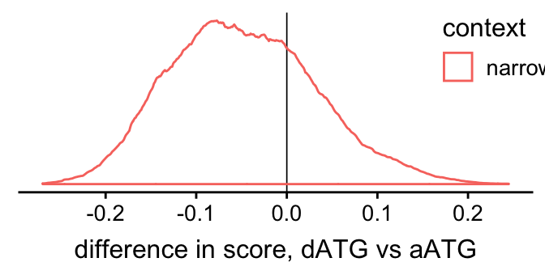

### For highly translated genes, most dATG narrow scores are much less than aATG

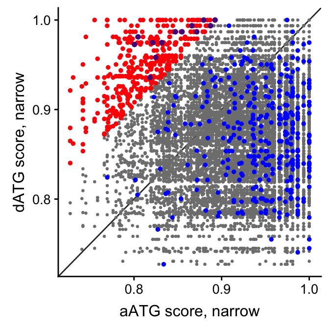

Red: high dATG vs aATG **Kozak** score. Blue: highly translated. Purple: both.

### Small negative correlation between dATG and aATG score narrow

R = -0.003

### For highly translated genes, most dATG wide scores are much less than aATG

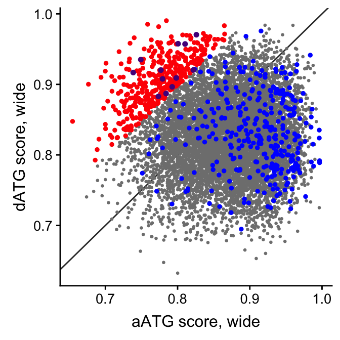

Red: high dATG vs aATG **Kozak** score. Blue: highly translated. Purple: both.

R = 0.001

## Genes with unusual dATG vs aATG narrow score

Those genes are in this list:

```
## # A tibble: 400 x 3
##    Gene                                          aATG.scorekn d1.scorekn
##    <chr>                                                <dbl>      <dbl>
##  1 HISTO_GI.Contig363.eannot.1210.final_new             0.755      1
##  2 HISTO_ZZ.Contig127a.eannot.1329.final_new            0.745      0.981
##  3 HISTO_ZZ.Contig127b-snap.107.final_new               0.769      1
##  4 HISTO_ZY.Contig518.eannot.1158.final_new             0.769      1
##  5 HISTO_DF.Contig537.Fgenesh_histo.18.final_new        0.769      0.994
##  6 HISTO_DF.Contig537.Fgenesh_histo.27.final_new        0.784      1
##  7 HISTO_JG.Contig206.eannot.1530.final_new             0.789      1
##  8 HISTO_DU.Contig190.eannot.1260.final_new             0.742      0.950
##  9 HISTO_ZE.Contig149.eannot.1280.final_new             0.731      0.936
## 10 HISTO_HS.Contig68-snap.41.final_new                  0.776      0.981
## # ... with 390 more rows
```

Some of these are highly translated (top 5%)

```
## # A tibble: 13 x 3
##    Gene                                             aATG.scorekn d1.scorekn
##    <chr>                                                   <dbl>      <dbl>
##  1 HISTO_DM.Contig933.eannot.1584.final_new                0.805      0.981
##  2 HISTO_ZL.Contig1161b.fgenesh_plus.39.final_new          0.801      0.973
##  3 HISTO_LF.Contig359.eannot.2154.final_new                0.821      0.975
##  4 HISTO_ZU.Contig65.eannot.2055.final_new                 0.832      0.975
##  5 HISTO_JG.Contig206.eannot.1555.final_new                0.847      0.987
##  6 HISTO_ZL.Contig1161d.Fgenesh_histo.113.final_new        0.825      0.958
##  7 HISTO_KF.Contig597.eannot.1395.final_new                0.855      0.987
##  8 HISTO_JG.Contig206.eannot.1477.final_new                0.866      0.994
##  9 HISTO_HS.Contig68.eannot.2018.final_new                 0.879      1
## 10 HISTO_DM.Contig940.eannot.1234.final_new                0.818      0.936
## 11 HISTO_DF.Contig537.eannot.1325.final_new                0.872      0.987
## 12 HISTO_JG.Contig207.eannot.1394.final_new                0.893      1
## 13 HISTO_FX.Contig167.fgenesh_plus.16.final_new            0.887      0.994
```

### dATG in frame with ATG, narrow

Files with high difference in narrow score, filtered for reasonable amounts of RNA, in frame. Saved to *dvsaATG_highdiffn_inframe_Hc.txt*.

```
## # A tibble: 77 x 3
##    Gene                                     aATG.scorekn d1.scorekn
##    <chr>                                           <dbl>      <dbl>
##  1 HISTO_ZY.Contig518.eannot.1158.final_new        0.769      1
##  2 HISTO_JG.Contig206.eannot.1530.final_new        0.789      1
##  3 HISTO_DU.Contig190.eannot.1260.final_new        0.742      0.950
##  4 HISTO_DF.Contig537.eannot.1403.final_new        0.797      0.994
##  5 HISTO_EA.Contig33.eannot.1524.final_new         0.804      0.994
##  6 HISTO_BP.Contig459.eannot.1499.final_new        0.789      0.979
##  7 HISTO_BP.Contig457.eannot.1663.final_new        0.793      0.979
##  8 HISTO_GY.Contig460.eannot.1766.final_new        0.741      0.926
##  9 HISTO_ZU.Contig65.eannot.2107.final_new         0.802      0.987
## 10 HISTO_GY.Contig460-snap.130.final_new           0.798      0.979
## # ... with 67 more rows
```

### dATG out of frame with ATG, narrow

Files with high difference in narrow score, filtered for reasonable amounts of RNA, out of frame. Saved to *dvsaATG_highdiffn_outframe_Hc.txt*.

```
## # A tibble: 62 x 3
##    Gene                                            aATG.scorekn d1.scorekn
##    <chr>                                                  <dbl>      <dbl>
##  1 HISTO_GX.Contig297.eannot.1457.final_new               0.793      0.975
##  2 HISTO_ZL.Contig1131-snap.26.final_new                  0.819      1
##  3 HISTO_BP.Contig457.eannot.1757.final_new               0.797      0.975
##  4 HISTO_DA.Contig93.eannot.1937.final_new                0.809      0.987
##  5 HISTO_DY.Contig31.Fgenesh_Neurospora.84.final_…        0.804      0.981
##  6 HISTO_FE.Contig19.Fgenesh_histo.31.final_new           0.742      0.912
##  7 HISTO_ZT.Contig1128f.Fgenesh_histo.7.final_new         0.742      0.909
##  8 HISTO_LG.Contig392-snap.140.final_new                  0.766      0.929
##  9 HISTO_ZL.Contig1131-snap.36.final_new                  0.842      1
## 10 HISTO_JG.Contig206.Fgenesh_histo.113.final_new         0.823      0.975
## # ... with 52 more rows
```

### dATG in frame with ATG, wide

Files with high difference in wide score, filtered for reasonable amounts of RNA, in frame. Saved to *dvsaATG_highdiffw_inframe_Hc.txt*.

```
## # A tibble: 74 x 3
##    Gene                                           aATG.scorekw d1.scorekw
##    <chr>                                                 <dbl>      <dbl>
##  1 HISTO_JG.Contig206.eannot.1530.final_new              0.758      0.985
##  2 HISTO_BP.Contig459.eannot.1499.final_new              0.764      0.963
##  3 HISTO_ZL.Contig1161d-snap.42.final_new                0.655      0.848
##  4 HISTO_GY.Contig460.eannot.1766.final_new              0.713      0.905
##  5 HISTO_ZL.Contig1161b.fgenesh_plus.39.final_new        0.749      0.935
##  6 HISTO_ZT.Contig1128f.eannot.1131.final_new            0.725      0.910
##  7 HISTO_DF.Contig537.eannot.1394.final_new              0.709      0.890
##  8 HISTO_ZY.Contig518.eannot.1158.final_new              0.766      0.944
##  9 HISTO_ZU.Contig65.eannot.2107.final_new               0.776      0.953
## 10 HISTO_AZ.Contig47.eannot.1598.final_new               0.791      0.968
## # ... with 64 more rows
```

### dATG out of frame with ATG, wide

Files with high difference in wide score, filtered for reasonable amounts of RNA, out of frame. Saved to *dvsaATG_highdiffw_outframe_Hc.txt*.

```
## # A tibble: 67 x 3
##    Gene                                            aATG.scorekw d1.scorekw
##    <chr>                                                  <dbl>      <dbl>
##  1 HISTO_ZL.Contig1161b.eannot.1273.final_new             0.720      0.910
##  2 HISTO_DY.Contig31.Fgenesh_Neurospora.84.final_…        0.760      0.948
##  3 HISTO_DY.Contig31-snap.42.final_new                    0.753      0.936
##  4 HISTO_DM.Contig940.eannot.1234.final_new               0.739      0.917
##  5 HISTO_DA.Contig93.eannot.1937.final_new                0.778      0.951
##  6 HISTO_GX.Contig297.eannot.1457.final_new               0.788      0.958
##  7 HISTO_HS.Contig68.eannot.2169.final_new                0.779      0.946
##  8 HISTO_ZL.Contig1131-snap.26.final_new                  0.790      0.947
##  9 HISTO_AL.Contig317.Fgenesh_histo.133.final_new         0.785      0.941
## 10 HISTO_ZE.Contig158.Fgenesh_Aspergillus.90.fina…        0.817      0.969
## # ... with 57 more rows
```

## Compare score difference to localization predictions

### Load predictions from mitofates

In input file *Histo_mitofates.txt*.

### Hc Genes with high dATG vs aATG score *are* enriched in mitochondrial presequences

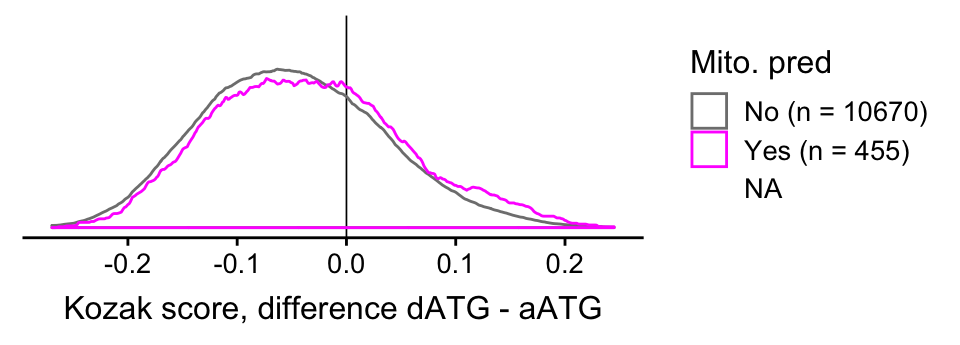

### Correlations between d1 score, d1 frame, and localization

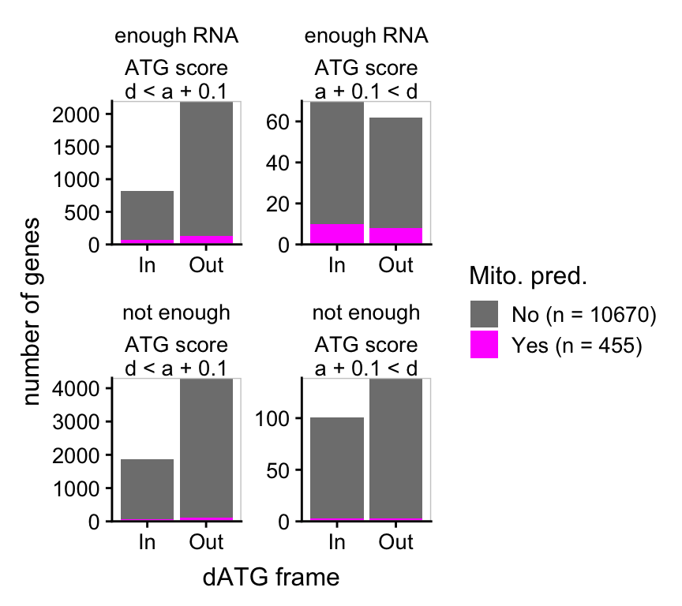

### Count dATG vs ATG score, d1 frame, mito pre, enough RNA

```
## # A tibble: 16 x 5
## # Groups:   enoughR, d1vsaw0p1, d1.framefac [?]
##    enoughR d1vsaw0p1 d1.framefac Pred_preseq     n
##    <fct>   <fct>     <fct>       <fct>       <int>
##  1 Yes     d1lo      In          No            746
##  2 Yes     d1lo      In          Yes            69
##  3 Yes     d1lo      Out         No           2066
##  4 Yes     d1lo      Out         Yes           133
##  5 Yes     d1hi      In          No             60
##  6 Yes     d1hi      In          Yes            10
##  7 Yes     d1hi      Out         No             54
##  8 Yes     d1hi      Out         Yes             8
##  9 No      d1lo      In          No           1792
## 10 No      d1lo      In          Yes            74
## 11 No      d1lo      Out         No           4193
## 12 No      d1lo      Out         Yes           118
## 13 No      d1hi      In          No             98
## 14 No      d1hi      In          Yes             3
## 15 No      d1hi      Out         No            136
## 16 No      d1hi      Out         Yes             3
```

### Hc mito-localized genes also do not have a distinctive aATG context

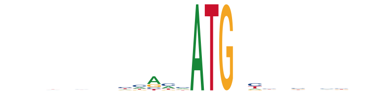

## Genes with unusual dATG vs aATG narrow score AND predicted mito loc

Those genes are in this list:

```
## # A tibble: 29 x 6
##    Gene                   aATG.scorekn d1.scorekn d1.frame d1.posATG   RPF
##    <chr>                         <dbl>      <dbl>    <dbl>     <dbl> <dbl>
##  1 HISTO_DU.Contig190.ea…        0.742      0.950        0       261  7.39
##  2 HISTO_BP.Contig457.ea…        0.793      0.979        0       141  7.41
##  3 HISTO_GY.Contig460.ea…        0.741      0.926        0        27  6.24
##  4 HISTO_DM.Contig933.ea…        0.805      0.981        0       132  8.64
##  5 HISTO_DU.Contig204-sn…        0.807      0.975        0       102  7.40
##  6 HISTO_JG.Contig206.ea…        0.789      0.950        0         9  6.41
##  7 HISTO_ZL.Contig1131-s…        0.842      1            2        53  2.54
##  8 HISTO_ZE.Contig149-sn…        0.800      0.958        0       102  3.95
##  9 HISTO_DM.Contig933.ea…        0.826      0.981        0       102  6.10
## 10 HISTO_LG.Contig392.ea…        0.820      0.975        0        60  7.71
## # ... with 19 more rows
```

### less strong biases, but in frame dATG

```
## # A tibble: 174 x 5
##    Gene                            aATG.scorekn d1.scorekn d1.posATG   RPF
##    <chr>                                  <dbl>      <dbl>     <dbl> <dbl>
##  1 HISTO_DU.Contig190.eannot.1260…        0.742      0.950       261  7.39
##  2 HISTO_BP.Contig457.eannot.1663…        0.793      0.979       141  7.41
##  3 HISTO_GY.Contig460.eannot.1766…        0.741      0.926        27  6.24
##  4 HISTO_DM.Contig933.eannot.1584…        0.805      0.981       132  8.64
##  5 HISTO_DU.Contig204-snap.2.fina…        0.807      0.975       102  7.40
##  6 HISTO_JG.Contig206.eannot.1494…        0.789      0.950         9  6.41
##  7 HISTO_ZE.Contig149-snap.30.fin…        0.800      0.958       102  3.95
##  8 HISTO_DM.Contig933.eannot.1625…        0.826      0.981       102  6.10
##  9 HISTO_LG.Contig392.eannot.1763…        0.820      0.975        60  7.71
## 10 HISTO_ZL.Contig1161c.eannot.15…        0.758      0.911       231  7.84
## 11 HISTO_LAF.Contig3-snap.1.final…        0.840      0.975        45 NA
## 12 HISTO_ZL.Contig1161a.Fgenesh_h…        0.854      0.987        24  8.09
## 13 HISTO_KF.Contig601.eannot.1321…        0.847      0.973        12  3.16
## 14 HISTO_ZL.Contig1161d.eannot.14…        0.776      0.902        27  8.35
## 15 HISTO_ZT.Contig1089.eannot.164…        0.840      0.958       105  7.87
## 16 HISTO_ZT.Contig1089.Fgenesh_hi…        0.819      0.933       330  6.88
## 17 HISTO_ZL.Contig1131.Fgenesh_hi…        0.814      0.924         9  3.00
## 18 HISTO_LG.Contig392.eannot.1774…        0.834      0.937        66  5.63
## 19 HISTO_AL.Contig317.Fgenesh_Asp…        0.852      0.950        54 NA
## 20 HISTO_ZT.Contig1089.eannot.154…        0.769      0.866        12  6.21
## # ... with 154 more rows
```

Back to table of contents